# Employee Attrition: Preliminary Insights

## 1 Business Case (Fictional)

NovaTech Solutions, a mid-sized tech company, has experienced an increase in attrition over the past year. The company’s leadership is concerned about this trend and has asked the HR Analytics team to explore patterns and trends in employee attrition. NovaTech already uses SQL for its database operations, making it possible to leverage their existing infrastructure for data analysis and reporting.

The HR Analytics team is tasked with creating:

1. A detailed report summarizing key trends and insights using SQL-based analyses.
2. An interactive dashboard that allows stakeholders to explore data dynamically and focus on specific areas, such as departments, roles, and satisfaction levels.

**Aside: Dataset Used**

For this demo portfolio project, I used an IBM employee dataset obtained from Kaggle. The dataset was split into two tables:

- **`employee_info`**: Contains demographic and job-related information.
- **`employee_exp`**: Includes data on employee experience, such as job satisfaction, job involvement, and work-life balance.

I set up a PostgreSQL database using **pgAdmin** to import these tables and perform analyses. This setup mimics the data pipeline and infrastructure used by many organizations for SQL-based data exploration and reporting.

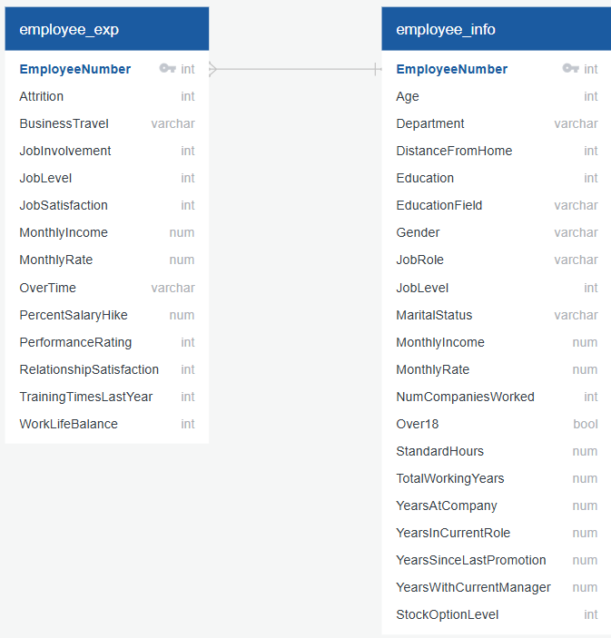

```r
#loading packages
suppressMessages(
suppressWarnings(
  pacman::p_load(DBI,
                 RPostgres,
                 tidyverse,
                 dplyr,
                 highcharter)
)
)

# Set up connection
con <- dbConnect(
  RPostgres::Postgres(),
  dbname = "employee_experience",
  host = "localhost",
  port = 5432,
  user = "postgres",
  password = "password"
)
```

## 2 Dataset Overview

```sql
SELECT *
FROM employee_info
LIMIT 10;
```

Displaying records 1 - 10

| EmployeeNumber | Age | Department | DistanceFromHome | Education | EducationField | Gender | JobRole | JobLevel | MaritalStatus | MonthlyIncome | MonthlyRate | NumCompaniesWorked | Over18 | StandardHours | TotalWorkingYears | YearsAtCompany | YearsInCurrentRole | YearsSinceLastPromotion | YearsWithCurrManager | StockOptionLevel |
| --- | --- | --- | --- | --- | --- | --- | --- | --- | --- | --- | --- | --- | --- | --- | --- | --- | --- | --- | --- | --- |
| 1 | 41 | Sales | 1 | 2 | Life Sciences | Female | Sales Executive | 2 | Single | 5993 | 19479 | 8 | TRUE | 80 | 0 | 8 | 6 | 4 | 0 | 5 |
| 2 | 49 | Research & Development | 8 | 1 | Life Sciences | Male | Research Scientist | 2 | Married | 5130 | 24907 | 1 | TRUE | 80 | 1 | 10 | 10 | 7 | 1 | 7 |
| 4 | 37 | Research & Development | 2 | 2 | Other | Male | Laboratory Technician | 1 | Single | 2090 | 2396 | 6 | TRUE | 80 | 0 | 7 | 0 | 0 | 0 | 0 |
| 5 | 33 | Research & Development | 3 | 4 | Life Sciences | Female | Research Scientist | 1 | Married | 2909 | 23159 | 1 | TRUE | 80 | 0 | 8 | 8 | 7 | 3 | 0 |
| 7 | 27 | Research & Development | 2 | 1 | Medical | Male | Laboratory Technician | 1 | Married | 3468 | 16632 | 9 | TRUE | 80 | 1 | 6 | 2 | 2 | 2 | 2 |
| 8 | 32 | Research & Development | 2 | 2 | Life Sciences | Male | Laboratory Technician | 1 | Single | 3068 | 11864 | 0 | TRUE | 80 | 0 | 8 | 7 | 7 | 3 | 6 |
| 10 | 59 | Research & Development | 3 | 3 | Medical | Female | Laboratory Technician | 1 | Married | 2670 | 9964 | 4 | TRUE | 80 | 3 | 12 | 1 | 0 | 0 | 0 |
| 11 | 30 | Research & Development | 24 | 1 | Life Sciences | Male | Laboratory Technician | 1 | Divorced | 2693 | 13335 | 1 | TRUE | 80 | 1 | 1 | 1 | 0 | 0 | 0 |
| 12 | 38 | Research & Development | 23 | 3 | Life Sciences | Male | Manufacturing Director | 3 | Single | 9526 | 8787 | 0 | TRUE | 80 | 0 | 10 | 9 | 7 | 1 | 8 |
| 13 | 36 | Research & Development | 27 | 3 | Medical | Male | Healthcare Representative | 2 | Married | 5237 | 16577 | 6 | TRUE | 80 | 2 | 17 | 7 | 7 | 7 | 7 |

```sql
SELECT *
FROM employee_exp
LIMIT 10;
```

Displaying records 1 - 10

| EmployeeNumber | Attrition | BusinessTravel | JobInvolvement | JobLevel | JobSatisfaction | MonthlyIncome | MonthlyRate | OverTime | PercentSalaryHike | PerformanceRating | RelationshipSatisfaction | TrainingTimesLastYear | WorkLifeBalance |
| --- | --- | --- | --- | --- | --- | --- | --- | --- | --- | --- | --- | --- | --- |
| 1 | 1 | Travel_Rarely | 3 | 2 | 4 | 5993 | 19479 | Yes | 11 | 3 | 1 | 0 | 1 |
| 2 | 0 | Travel_Frequently | 2 | 2 | 2 | 5130 | 24907 | No | 23 | 4 | 4 | 3 | 3 |
| 4 | 1 | Travel_Rarely | 2 | 1 | 3 | 2090 | 2396 | Yes | 15 | 3 | 2 | 3 | 3 |
| 5 | 0 | Travel_Frequently | 3 | 1 | 3 | 2909 | 23159 | Yes | 11 | 3 | 3 | 3 | 3 |
| 7 | 0 | Travel_Rarely | 3 | 1 | 2 | 3468 | 16632 | No | 12 | 3 | 4 | 3 | 3 |
| 8 | 0 | Travel_Frequently | 3 | 1 | 4 | 3068 | 11864 | No | 13 | 3 | 3 | 2 | 2 |
| 10 | 0 | Travel_Rarely | 4 | 1 | 1 | 2670 | 9964 | Yes | 20 | 4 | 1 | 3 | 2 |
| 11 | 0 | Travel_Rarely | 3 | 1 | 3 | 2693 | 13335 | No | 22 | 4 | 2 | 2 | 3 |
| 12 | 0 | Travel_Frequently | 2 | 3 | 3 | 9526 | 8787 | No | 21 | 4 | 2 | 2 | 3 |
| 13 | 0 | Travel_Rarely | 3 | 2 | 3 | 5237 | 16577 | No | 13 | 3 | 2 | 3 | 2 |

## 3 Attrition Rate Analysis

### 3.1 Overall Attrition Rate

```sql
SELECT ROUND(AVG("Attrition")*100,2) AS attrition_rate
FROM employee_exp;
```

1 records

| attrition_rate |
| --- |
| 16.12 |

### 3.2 Attrition Rate by Organizational Factors

**Department**

```sql
SELECT ei."Department", ROUND(AVG("Attrition")*100,2) AS attrition_rate
FROM employee_exp AS ee
LEFT JOIN employee_info AS ei
ON ee."EmployeeNumber" = ei."EmployeeNumber"
GROUP BY "Department"
ORDER BY attrition_rate DESC;
```

3 records

| Department | attrition_rate |
| --- | --- |
| Sales | 20.63 |
| Human Resources | 19.05 |
| Research & Development | 13.84 |

```r
# Fetch data from SQL query
attrition_department <- dbGetQuery(con, "
  SELECT ei.\"Department\", ROUND(AVG(\"Attrition\")*100,2) AS attrition_rate
  FROM employee_exp AS ee
  LEFT JOIN employee_info AS ei
  ON ee.\"EmployeeNumber\" = ei.\"EmployeeNumber\"
  GROUP BY \"Department\"
  ORDER BY attrition_rate DESC;
")

# Create an interactive bar chart
hchart(
  attrition_department,
  "column",
  hcaes(x = Department, y = attrition_rate),
  name = "Attrition Rate"
) %>%
  hc_title(text = "Attrition Rate by Department") %>%
  hc_xAxis(title = list(text = "Department")) %>%
  hc_yAxis(title = list(text = "Attrition Rate (%)")) %>%
  hc_colors("steelblue")
```

[interactive chart not shown]

**Job Role**

```sql
SELECT "JobRole", ROUND(AVG("Attrition")*100,2) AS attrition_rate
FROM employee_info ei
JOIN employee_exp ee ON ei."EmployeeNumber" = ee."EmployeeNumber"
GROUP BY "JobRole"
ORDER BY attrition_rate DESC;
```

9 records

| JobRole | attrition_rate |
| --- | --- |
| Sales Representative | 39.76 |
| Laboratory Technician | 23.94 |
| Human Resources | 23.08 |
| Sales Executive | 17.48 |
| Research Scientist | 16.10 |
| Manufacturing Director | 6.90 |
| Healthcare Representative | 6.87 |
| Manager | 4.90 |
| Research Director | 2.50 |

```r
# Fetch data from SQL query
attrition_role <- dbGetQuery(con, "
  SELECT ei.\"JobRole\", ROUND(AVG(\"Attrition\")*100,2) AS attrition_rate
  FROM employee_info AS ei
  LEFT JOIN employee_exp AS ee
  ON ei.\"EmployeeNumber\" = ee.\"EmployeeNumber\"
  GROUP BY \"JobRole\"
  ORDER BY attrition_rate DESC;
")

# Create an interactive bar chart
hchart(
  attrition_role,
  "column",
  hcaes(x = JobRole, y = attrition_rate),
  name = "Attrition Rate"
) %>%
  hc_title(text = "Attrition Rate by Job Role") %>%
  hc_xAxis(title = list(text = "Job Role")) %>%
  hc_yAxis(title = list(text = "Attrition Rate (%)")) %>%
  hc_colors("steelblue")
```

[interactive chart not shown]

**Monthly Income**

```sql
--- Specify a CTE
WITH Quartiles AS (
  SELECT PERCENTILE_CONT(0.25) WITHIN GROUP (ORDER BY "MonthlyIncome") AS Q1,
         PERCENTILE_CONT(0.50) WITHIN GROUP (ORDER BY "MonthlyIncome") AS Q2,
         PERCENTILE_CONT(0.75) WITHIN GROUP (ORDER BY "MonthlyIncome") AS Q3
  FROM employee_exp
)

--- Apply the CTE

SELECT CASE
         WHEN "MonthlyIncome" < Quartiles.Q1 THEN
             CONCAT('Low Income (<', ROUND(Quartiles.Q1::numeric, 2), ')')
         WHEN "MonthlyIncome" >= Quartiles.Q1 AND "MonthlyIncome" < Quartiles.Q2 THEN
             CONCAT('Lower Mid Income (', ROUND(Quartiles.Q1::numeric, 2), '-', ROUND(Quartiles.Q2::numeric, 2), ')')
         WHEN "MonthlyIncome" >= Quartiles.Q2 AND "MonthlyIncome" < Quartiles.Q3 THEN
             CONCAT('Upper Mid Income (', ROUND(Quartiles.Q2::numeric, 2), '-', ROUND(Quartiles.Q3::numeric, 2), ')')
         ELSE
             CONCAT('High Income (>', ROUND(Quartiles.Q3::numeric, 2), ')')
       END AS income_bracket,
       ROUND(AVG("Attrition")*100, 2) AS attrition_rate
FROM employee_exp, Quartiles
GROUP BY income_bracket
ORDER BY attrition_rate DESC;
```

4 records

| income_bracket | attrition_rate |
| --- | --- |
| Low Income (<2911.00) | 29.43 |
| Lower Mid Income (2911.00-4919.00) | 14.13 |
| Upper Mid Income (4919.00-8379.00) | 10.63 |
| High Income (>8379.00) | 10.33 |

```r
# Fetch data from SQL query

attrition_income <- dbGetQuery(con, "
WITH Quartiles AS (
  SELECT PERCENTILE_CONT(0.25) WITHIN GROUP (ORDER BY \"MonthlyIncome\") AS Q1,
         PERCENTILE_CONT(0.50) WITHIN GROUP (ORDER BY \"MonthlyIncome\") AS Q2,
         PERCENTILE_CONT(0.75) WITHIN GROUP (ORDER BY \"MonthlyIncome\") AS Q3
  FROM employee_exp
)

SELECT CASE
         WHEN \"MonthlyIncome\" < Quartiles.Q1 THEN
             CONCAT('Low Income (<', ROUND(Quartiles.Q1::numeric, 2), ')')
         WHEN \"MonthlyIncome\" >= Quartiles.Q1 AND \"MonthlyIncome\" < Quartiles.Q2 THEN
             CONCAT('Lower Mid Income (', ROUND(Quartiles.Q1::numeric, 2), '-', ROUND(Quartiles.Q2::numeric, 2), ')')
         WHEN \"MonthlyIncome\" >= Quartiles.Q2 AND \"MonthlyIncome\" < Quartiles.Q3 THEN
             CONCAT('Upper Mid Income (', ROUND(Quartiles.Q2::numeric, 2), '-', ROUND(Quartiles.Q3::numeric, 2), ')')
         ELSE
             CONCAT('High Income (>', ROUND(Quartiles.Q3::numeric, 2), ')')
       END AS income_bracket,
       ROUND(AVG(\"Attrition\")*100, 2) AS attrition_rate
FROM employee_exp, Quartiles
GROUP BY income_bracket
ORDER BY attrition_rate DESC;

")

# Create an interactive bar chart
hchart(
  attrition_income,
  "column",
  hcaes(x = income_bracket, y = attrition_rate),
  name = "Attrition Rate"
) %>%
  hc_title(text = "Attrition Rate by Monthly Income Bracket") %>%
  hc_xAxis(title = list(text = "Monthly Income")) %>%
  hc_yAxis(title = list(text = "Attrition Rate (%)")) %>%
  hc_colors("steelblue")
```

[interactive chart not shown]

**Years Since Last Promotion**

```sql
SELECT CASE
         WHEN "YearsSinceLastPromotion" < 2 THEN 'Less than 2'
         WHEN "YearsSinceLastPromotion" BETWEEN 2 AND 4 THEN 'Between 2 and 4'
         WHEN "YearsSinceLastPromotion" BETWEEN 5 AND 7 THEN 'Between 5 and 7'
         WHEN "YearsSinceLastPromotion" > 7 THEN 'More than 7'
       END AS last_promotion,
       ROUND(AVG("Attrition") * 100,2) AS attrition_rate
FROM employee_info ei
JOIN employee_exp ee ON ei."EmployeeNumber" = ee."EmployeeNumber"
GROUP BY
       CASE
         WHEN "YearsSinceLastPromotion" < 2 THEN 'Less than 2'
         WHEN "YearsSinceLastPromotion" BETWEEN 2 AND 4 THEN 'Between 2 and 4'
         WHEN "YearsSinceLastPromotion" BETWEEN 5 AND 7 THEN 'Between 5 and 7'
         WHEN "YearsSinceLastPromotion" > 7 THEN 'More than 7'
       END
ORDER BY attrition_rate DESC;
```

4 records

| last_promotion | attrition_rate |
| --- | --- |
| Less than 2 | 27.91 |
| Between 2 and 4 | 16.20 |
| Between 5 and 7 | 11.53 |
| More than 7 | 7.60 |

```r
# Fetch data from SQL query

attrition_promotion <- dbGetQuery(con, "
SELECT CASE
         WHEN \"YearsSinceLastPromotion\" < 2 THEN 'Less than 2'
         WHEN \"YearsSinceLastPromotion\" BETWEEN 2 AND 4 THEN 'Between 2 and 4'
         WHEN \"YearsSinceLastPromotion\" BETWEEN 5 AND 7 THEN 'Between 5 and 7'
         WHEN \"YearsSinceLastPromotion\" > 7 THEN 'More than 7'
       END AS last_promotion,
       ROUND(AVG(\"Attrition\") * 100,2) AS attrition_rate
FROM employee_info ei
JOIN employee_exp ee ON ei.\"EmployeeNumber\" = ee.\"EmployeeNumber\"
GROUP BY
       CASE
         WHEN \"YearsSinceLastPromotion\" < 2 THEN 'Less than 2'
         WHEN \"YearsSinceLastPromotion\" BETWEEN 2 AND 4 THEN 'Between 2 and 4'
         WHEN \"YearsSinceLastPromotion\" BETWEEN 5 AND 7 THEN 'Between 5 and 7'
         WHEN \"YearsSinceLastPromotion\" > 7 THEN 'More than 7'
       END
ORDER BY attrition_rate DESC;
")

# Create an interactive bar chart
hchart(
  attrition_promotion,
  "column",
  hcaes(x = last_promotion, y = attrition_rate),
  name = "Attrition Rate"
) %>%
  hc_title(text = "Attrition Rate by Years Since Last Promotion") %>%
  hc_xAxis(title = list(text = "Years Since Last Promotion")) %>%
  hc_yAxis(title = list(text = "Attrition Rate (%)")) %>%
  hc_colors("steelblue")
```

[interactive chart not shown]

**Role Tenure**

```sql
SELECT CASE
         WHEN "YearsInCurrentRole" < 2 THEN 'Less than 2'
         WHEN "YearsInCurrentRole" BETWEEN 2 AND 4 THEN 'Between 2 and 4'
         WHEN "YearsInCurrentRole" BETWEEN 5 AND 7 THEN 'Between 5 and 7'
         WHEN "YearsInCurrentRole" > 7 THEN 'More than 7'
       END AS years_in_current_role,
       ROUND(AVG("Attrition") * 100,2) AS attrition_rate
FROM employee_info ei
JOIN employee_exp ee ON ei."EmployeeNumber" = ee."EmployeeNumber"
GROUP BY
       CASE
         WHEN "YearsInCurrentRole" < 2 THEN 'Less than 2'
         WHEN "YearsInCurrentRole" BETWEEN 2 AND 4 THEN 'Between 2 and 4'
         WHEN "YearsInCurrentRole" BETWEEN 5 AND 7 THEN 'Between 5 and 7'
         WHEN "YearsInCurrentRole" > 7 THEN 'More than 7'
       END
ORDER BY attrition_rate DESC;
```

4 records

| years_in_current_role | attrition_rate |
| --- | --- |
| Less than 2 | 34.88 |
| Between 2 and 4 | 18.08 |
| Between 5 and 7 | 11.33 |
| More than 7 | 10.42 |

```r
# Fetch data from SQL query

attrition_tenure <- dbGetQuery(con, "
SELECT CASE
         WHEN \"YearsInCurrentRole\" < 2 THEN 'Less than 2'
         WHEN \"YearsInCurrentRole\" BETWEEN 2 AND 4 THEN 'Between 2 and 4'
         WHEN \"YearsInCurrentRole\" BETWEEN 5 AND 7 THEN 'Between 5 and 7'
         WHEN \"YearsInCurrentRole\" > 7 THEN 'More than 7'
       END AS years_in_current_role,
       ROUND(AVG(\"Attrition\"),2) * 100 AS attrition_rate
FROM employee_info ei
JOIN employee_exp ee ON ei.\"EmployeeNumber\" = ee.\"EmployeeNumber\"
GROUP BY
       CASE
         WHEN \"YearsInCurrentRole\" < 2 THEN 'Less than 2'
         WHEN \"YearsInCurrentRole\" BETWEEN 2 AND 4 THEN 'Between 2 and 4'
         WHEN \"YearsInCurrentRole\" BETWEEN 5 AND 7 THEN 'Between 5 and 7'
         WHEN \"YearsInCurrentRole\" > 7 THEN 'More than 7'
       END
ORDER BY attrition_rate DESC;
")

# Create an interactive bar chart
hchart(
  attrition_tenure,
  "column",
  hcaes(x = years_in_current_role, y = attrition_rate),
  name = "Attrition Rate"
) %>%
  hc_title(text = "Attrition Rate by Years in Current Role") %>%
  hc_xAxis(title = list(text = "Years in Current Role")) %>%
  hc_yAxis(title = list(text = "Attrition Rate (%)")) %>%
  hc_colors("steelblue")
```

[interactive chart not shown]

**Overtime Status**

```sql
SELECT "OverTime", ROUND(AVG("Attrition")*100,2) AS attrition_rate
FROM employee_exp
GROUP BY "OverTime"
ORDER BY attrition_rate DESC;
```

2 records

| OverTime | attrition_rate |
| --- | --- |
| Yes | 30.53 |
| No | 10.44 |

```r
# Fetch data from SQL query

attrition_overtime <- dbGetQuery(con, "
SELECT \"OverTime\", ROUND(AVG(\"Attrition\")*100,2) AS attrition_rate
FROM employee_exp
GROUP BY \"OverTime\"
ORDER BY attrition_rate DESC;
")

# Create an interactive bar chart
hchart(
  attrition_overtime,
  "column",
  hcaes(x = "OverTime", y = attrition_rate),
  name = "Attrition Rate"
) %>%
  hc_title(text = "Attrition Rate by Overtime Status") %>%
  hc_xAxis(title = list(text = "Overtime Status")) %>%
  hc_yAxis(title = list(text = "Attrition Rate (%)")) %>%
  hc_colors("steelblue")
```

[interactive chart not shown]

#### 3.2.1 Key Findings: Organizational-Level Factors

**Departmental and Job Role Trends**

- **Department**: The Sales department has the highest attrition rate (20.63%), while Research & Development has the lowest (13.84%). This descriptive pattern suggests that there may be specific factors within the Sales department contributing to higher turnover, such as work pressure or job satisfaction. A deeper investigation into these factors could help identify targeted retention strategies, such as addressing work environment or culture.
- **Job Role:** Sales Representatives have the highest attrition rate (39.8%), while Research Directors have the lowest (2.50%). This turnover pattern may be partly influenced by the departments these roles belong to, as the Sales department shows the highest attrition rate and the Research & Development department the lowest.

To better understand the organizational-level factors driving attrition, further analysis is needed to investigate if job roles, departments, or both are influencing turnover. If departmental factors (e.g., culture, pressure, unrealistic expectations) are driving attrition, strategies targeting broader cultural or environmental changes in departments like Sales might be more effective. On the other hand, if role-specific factors (e.g., nature of sales work) are contributing to turnover, strategies like role redesign or additional training might be more beneficial.

**Income Bracket and Attrition**

- Employees earning less than $2911 a month (25th percentile) have a high attrition rate (29.4%), while those earning more than $8379 a month (75th percentile) have a low one (10.33%). This suggests a potential relationship between income and attrition, with lower-income employees more likely to leave the organization. This could reflect external factors, such as better opportunities elsewhere, or internal factors like dissatisfaction with compensation. To confirm this relationship, further analysis would be needed to explore how income interacts with other variables such as job satisfaction or career progression.

**Promotion Timing and Tenure:**

- There appears to be a general trend where attrition rates decrease as tenure increases. This could suggest that employees who have been with the company longer are more likely to stay, perhaps due to stronger organizational ties or more investment in their roles. Further analysis could explore if tenure correlates with other factors like job satisfaction, career progression, or promotion opportunities.

**Years Since Promotion:**

- There also seems to be a pattern where attrition rates decrease as the number of years since the last promotion increases. Employees who have not been promoted for over five years tend to have low attrition rates, potentially because they have already reached higher levels within the organization where promotion opportunities are limited and with which they are are satisfied. However, more analyses would be needed to understand the nuances of this trend.

**Overtime and Attrition:**

- Employees who regularly work overtime show a high attrition rate (30.5%). This descriptive pattern suggests that work-life balance challenges may be a factor in turnover, as employees with higher overtime commitments might experience burnout or dissatisfaction. To address this, the company could explore ways to reduce overtime demands, promote work-life balance, and offer additional support for employees experiencing burnout. However, further analysis is required to confirm whether overtime is a direct driver of attrition or if other factors, such as job satisfaction or involvement, are stronger contributors.

### 3.3 Attrition Rates by Demographic Factors

**Age**

```sql
SELECT CASE
         WHEN "Age" < 30 THEN 'Under 30'
         WHEN "Age" BETWEEN 30 AND 40 THEN '30-40'
         WHEN "Age" BETWEEN 41 AND 50 THEN '41-50'
         ELSE 'Over 50'
       END AS age_group,
       ROUND(AVG("Attrition")*100,2) AS attrition_rate
FROM employee_info ei
JOIN employee_exp ee ON ei."EmployeeNumber" = ee."EmployeeNumber"
GROUP BY age_group
ORDER BY attrition_rate DESC;
```

4 records

| age_group | attrition_rate |
| --- | --- |
| Under 30 | 27.91 |
| 30-40 | 13.84 |
| Over 50 | 12.59 |
| 41-50 | 10.56 |

```r
attrition_age <- dbGetQuery(con, "
  SELECT CASE
         WHEN \"Age\" < 30 THEN 'Under 30'
         WHEN \"Age\" BETWEEN 30 AND 40 THEN '30-40'
         WHEN \"Age\" BETWEEN 41 AND 50 THEN '41-50'
         ELSE 'Over 50'
       END AS age_group,
       ROUND(AVG(\"Attrition\")*100,2) AS attrition_rate
FROM employee_info ei
JOIN employee_exp ee ON ei.\"EmployeeNumber\" = ee.\"EmployeeNumber\"
GROUP BY age_group
ORDER BY attrition_rate DESC;
")

# Create the Highcharter bar chart
hchart(
  attrition_age,
  type = "column",  # Bar chart type
  hcaes(x = age_group, y = attrition_rate),  # Correct column names
  name = "Attrition Rate"
) %>%
  hc_title(text = "Attrition Rate by Age") %>%
  hc_xAxis(title = list(text = "Age")) %>%
  hc_yAxis(title = list(text = "Attrition Rate (%)")) %>%
  hc_colors("steelblue")
```

[interactive chart not shown]

**Gender**

```sql
SELECT "Gender", ROUND(AVG("Attrition")*100,2) AS attrition_rate
FROM employee_info ei
JOIN employee_exp ee ON ei."EmployeeNumber" = ee."EmployeeNumber"
GROUP BY "Gender"
ORDER BY attrition_rate DESC;
```

2 records

| Gender | attrition_rate |
| --- | --- |
| Male | 17.01 |
| Female | 14.80 |

```r
attrition_gender <- dbGetQuery(con, "
  SELECT \"Gender\", ROUND(AVG(\"Attrition\")*100,2) AS attrition_rate
FROM employee_info ei
JOIN employee_exp ee ON ei.\"EmployeeNumber\" = ee.\"EmployeeNumber\"
GROUP BY \"Gender\"
ORDER BY attrition_rate DESC;
")

# Create the Highcharter bar chart
hchart(
  attrition_gender,
  type = "column",  # Bar chart type
  hcaes(x = "Gender", y = attrition_rate),  # Correct column names
  name = "Attrition Rate"
) %>%
  hc_title(text = "Attrition Rate by Gender") %>%
  hc_xAxis(title = list(text = "Gender")) %>%
  hc_yAxis(title = list(text = "Attrition Rate (%)")) %>%
  hc_colors("steelblue")
```

[interactive chart not shown]

**Distance from Home**

```sql
SELECT CASE
         WHEN "DistanceFromHome" < 5 THEN 'Under 5 km'
         WHEN "DistanceFromHome" BETWEEN 5 AND 10 THEN '5-10 km'
         ELSE 'Over 10 km'
       END AS distance_bracket,
       ROUND(AVG("Attrition")*100,2) AS attrition_rate
FROM employee_info ei
JOIN employee_exp ee ON ei."EmployeeNumber" = ee."EmployeeNumber"
GROUP BY distance_bracket
ORDER BY attrition_rate DESC;
```

3 records

| distance_bracket | attrition_rate |
| --- | --- |
| Over 10 km | 20.95 |
| 5-10 km | 14.60 |
| Under 5 km | 13.58 |

```r
attrition_distance <- dbGetQuery(con, "
  SELECT CASE
         WHEN \"DistanceFromHome\" < 5 THEN 'Under 5 km'
         WHEN \"DistanceFromHome\" BETWEEN 5 AND 10 THEN '5-10 km'
         ELSE 'Over 10 km'
       END AS distance_bracket,
       ROUND(AVG(\"Attrition\")*100,2) AS attrition_rate
FROM employee_info ei
JOIN employee_exp ee ON ei.\"EmployeeNumber\" = ee.\"EmployeeNumber\"
GROUP BY distance_bracket
ORDER BY attrition_rate DESC;
")

# Create the Highcharter bar chart
hchart(
  attrition_distance,
  type = "column",  # Bar chart type
  hcaes(x = distance_bracket, y = attrition_rate),  # Correct column names
  name = "Attrition Rate"
) %>%
  hc_title(text = "Attrition Rate by Distance from Home") %>%
  hc_xAxis(title = list(text = "Distance from Home")) %>%
  hc_yAxis(title = list(text = "Attrition Rate (%)")) %>%
  hc_colors("steelblue")
```

[interactive chart not shown]

**Education Level**

```sql
SELECT
    CASE
        WHEN "Education" = 1 THEN 'Below College'
        WHEN "Education" = 2 THEN 'College'
        WHEN "Education" = 3 THEN 'Bachelor'
        WHEN "Education" = 4 THEN 'Master'
        WHEN "Education" = 5 THEN 'Doctor'
        ELSE 'Unknown'
    END AS education_level,
    ROUND(AVG("Attrition")*100, 2) AS attrition_rate
FROM employee_info ei
JOIN employee_exp ee ON ei."EmployeeNumber" = ee."EmployeeNumber"
GROUP BY education_level
ORDER BY attrition_rate DESC;
```

5 records

| education_level | attrition_rate |
| --- | --- |
| Below College | 18.24 |
| Bachelor | 17.31 |
| College | 15.60 |
| Master | 14.57 |
| Doctor | 10.42 |

```r
attrition_education <- dbGetQuery(con, "
  SELECT
    CASE
      WHEN \"Education\" = 1 THEN 'Below College'
      WHEN \"Education\" = 2 THEN 'College'
      WHEN \"Education\" = 3 THEN 'Bachelor'
      WHEN \"Education\" = 4 THEN 'Master'
      WHEN \"Education\" = 5 THEN 'Doctor'
      ELSE 'Unknown'
    END AS education_level,
    ROUND(AVG(\"Attrition\") * 100, 2) AS attrition_rate
  FROM employee_info ei
  JOIN employee_exp ee ON ei.\"EmployeeNumber\" = ee.\"EmployeeNumber\"
  GROUP BY education_level
  ORDER BY attrition_rate DESC;
")

# Create the Highcharter bar chart
hchart(
  attrition_education,
  type = "column",  # Bar chart type
  hcaes(x = education_level, y = attrition_rate),  # Correct column names
  name = "Attrition Rate"
) %>%
  hc_title(text = "Attrition Rate by Education Level") %>%
  hc_xAxis(title = list(text = "Education Level")) %>%
  hc_yAxis(title = list(text = "Attrition Rate (%)")) %>%
  hc_colors("steelblue")
```

[interactive chart not shown]

#### 3.3.1 Key Findings: Demographic Factors

**Age**

- Employees under 30 have the highest attrition rate (27.91%), suggesting that younger employees may be more likely to leave the company. This could reflect a preference for career mobility, personal development opportunities, or dissatisfaction with their current role. In contrast, employees aged 41-50 have the lowest attrition rate (10.56%), potentially indicating greater job stability and satisfaction, as individuals in this age group may have established stronger ties to the organization. Additional analyses would be needed to investigate these hypotheses.

**Gender**

- Men show a slightly higher attrition rate (17.01%) than women (14.80%). While the difference is not substantial, it could signal a need to investigate gender-specific challenges. For instance, men may face different career pressures, or there may be external factors influencing their decisions to leave the company.

**Distance from Home**

- There appears to be a trend where employees who work farther from home (over 10 km) tend to have higher attrition rates. A possibility could be that longer commutes may negatively impact employee satisfaction and.or work-life balance. If this is the case, NovaTech might consider offering remote work options, flexible hours, or commuter benefits to address these challenges. However, I would recommend conducting further analyses before making changes to better understand the underlying drivers of this trend.

**Education Level**

- The highest attrition rate is seen among employees with the lowest education level (i.e., below college, 18.24%), while the lowest attrition rate is observed among those with a doctorate (10.42%). This could reflect several factors: employees with lower education levels may have fewer career advancement opportunities, leading to higher turnover, while those with higher education may have more job security and engagement in their roles. Additionally, employees with higher education levels might be more likely to stay in roles that align with their skills and aspirations, reducing their likelihood of leaving. Overall, more analyses would be needed to more confidently identify the factors contributing to this trend.

### 3.4 Attrition Rate by Employee Experience Factors

**Work-Life Balance**

```sql
SELECT
    CASE
        WHEN "WorkLifeBalance" = 1 THEN 'Bad'
        WHEN "WorkLifeBalance" = 2 THEN 'Good'
        WHEN "WorkLifeBalance" = 3 THEN 'Better'
        WHEN "WorkLifeBalance" = 4 THEN 'Best'
        ELSE 'Unknown'
    END AS work_life_balance,
    ROUND(AVG("Attrition")*100, 2) AS attrition_rate
FROM employee_exp
GROUP BY work_life_balance
ORDER BY work_life_balance;
```

4 records

| work_life_balance | attrition_rate |
| --- | --- |
| Bad | 31.25 |
| Best | 17.65 |
| Better | 14.22 |
| Good | 16.86 |

```r
# Fetch data from SQL query

attrition_wlb <- dbGetQuery(con, "
SELECT
    CASE
        WHEN \"WorkLifeBalance\" = 1 THEN 'Bad'
        WHEN \"WorkLifeBalance\" = 2 THEN 'Good'
        WHEN \"WorkLifeBalance\" = 3 THEN 'Better'
        WHEN \"WorkLifeBalance\" = 4 THEN 'Best'
        ELSE 'Unknown'
    END AS work_life_balance,
    ROUND(AVG(\"Attrition\")*100, 2) AS attrition_rate
FROM employee_exp
GROUP BY work_life_balance
ORDER BY attrition_rate;
")

# Create an interactive bar chart
hchart(
  attrition_wlb,
  "column",
  hcaes(x = work_life_balance, y = attrition_rate),
  name = "Attrition Rate"
) %>%
  hc_title(text = "Attrition Rate by Work-Life Balance Rating") %>%
  hc_xAxis(title = list(text = "Work-Life Balance Rating")) %>%
  hc_yAxis(title = list(text = "Attrition Rate (%)")) %>%
  hc_colors("steelblue")
```

[interactive chart not shown]

**Job Satisfaction**

```sql
SELECT
    CASE
        WHEN "JobSatisfaction" = 1 THEN 'Low'
        WHEN "JobSatisfaction" = 2 THEN 'Medium'
        WHEN "JobSatisfaction" = 3 THEN 'High'
        WHEN "JobSatisfaction" = 4 THEN 'Very High'
        ELSE 'Unknown'
    END AS job_satisfaction,
    ROUND(AVG("Attrition")*100, 2) AS attrition_rate
FROM employee_exp
GROUP BY job_satisfaction
ORDER BY attrition_rate DESC;
```

4 records

| job_satisfaction | attrition_rate |
| --- | --- |
| Low | 22.84 |
| High | 16.52 |
| Medium | 16.43 |
| Very High | 11.33 |

```r
# Fetch data from SQL query
attrition_job_sat <- dbGetQuery(con, "
  SELECT
    CASE
        WHEN \"JobSatisfaction\" = 1 THEN 'Low'
        WHEN \"JobSatisfaction\" = 2 THEN 'Medium'
        WHEN \"JobSatisfaction\" = 3 THEN 'High'
        WHEN \"JobSatisfaction\" = 4 THEN 'Very High'
        ELSE 'Unknown'
    END AS job_satisfaction,
    ROUND(AVG(\"Attrition\")*100, 2) AS attrition_rate
FROM employee_exp
GROUP BY job_satisfaction
ORDER BY attrition_rate DESC;
")

# Create an interactive bar chart
hchart(
  attrition_job_sat,
  "column",
  hcaes(x = job_satisfaction, y = attrition_rate),
  name = "Attrition Rate"
) %>%
  hc_title(text = "Attrition Rate by Job Satisfaction") %>%
  hc_xAxis(title = list(text = "Job Satisfaction")) %>%
  hc_yAxis(title = list(text = "Attrition Rate (%)")) %>%
  hc_colors("steelblue")
```

[interactive chart not shown]

**Relationship Satisfaction**

```sql
SELECT
    CASE
        WHEN "RelationshipSatisfaction" = 1 THEN 'Low'
        WHEN "RelationshipSatisfaction" = 2 THEN 'Medium'
        WHEN "RelationshipSatisfaction" = 3 THEN 'High'
        WHEN "RelationshipSatisfaction" = 4 THEN 'Very High'
        ELSE 'Unknown'
    END AS relationship_satisfaction,
    ROUND(AVG("Attrition")*100, 2) AS attrition_rate
FROM employee_exp
GROUP BY relationship_satisfaction
ORDER BY attrition_rate DESC;
```

4 records

| relationship_satisfaction | attrition_rate |
| --- | --- |
| Low | 20.65 |
| High | 15.47 |
| Medium | 14.85 |
| Very High | 14.81 |

```r
# Fetch data from SQL query
attrition_rel_sat <- dbGetQuery(con, "
  SELECT
    CASE
        WHEN \"RelationshipSatisfaction\" = 1 THEN 'Low'
        WHEN \"RelationshipSatisfaction\" = 2 THEN 'Medium'
        WHEN \"RelationshipSatisfaction\" = 3 THEN 'High'
        WHEN \"RelationshipSatisfaction\" = 4 THEN 'Very High'
        ELSE 'Unknown'
    END AS relationship_satisfaction,
    ROUND(AVG(\"Attrition\")*100, 2) AS attrition_rate
FROM employee_exp
GROUP BY relationship_satisfaction
ORDER BY attrition_rate DESC;
")

# Create an interactive bar chart
hchart(
  attrition_rel_sat,
  "column",
  hcaes(x = relationship_satisfaction, y = attrition_rate),
  name = "Attrition Rate"
) %>%
  hc_title(text = "Attrition Rate by Relationship Satisfaction") %>%
  hc_xAxis(title = list(text = "Relationship Satisfaction")) %>%
  hc_yAxis(title = list(text = "Attrition Rate (%)")) %>%
  hc_colors("steelblue")
```

[interactive chart not shown]

**Job Involvement**

```sql
SELECT
    CASE
        WHEN "JobInvolvement" = 1 THEN 'Low'
        WHEN "JobInvolvement" = 2 THEN 'Medium'
        WHEN "JobInvolvement" = 3 THEN 'High'
        WHEN "JobInvolvement" = 4 THEN 'Very High'
        ELSE 'Unknown'
    END AS job_involvement,
    ROUND(AVG("Attrition")*100, 2) AS attrition_rate
FROM employee_exp
GROUP BY job_involvement
ORDER BY attrition_rate DESC;
```

4 records

| job_involvement | attrition_rate |
| --- | --- |
| Low | 33.73 |
| Medium | 18.93 |
| High | 14.40 |
| Very High | 9.03 |

```r
# Fetch data from SQL query
attrition_job_inv<- dbGetQuery(con, "
  SELECT
    CASE
        WHEN \"JobInvolvement\" = 1 THEN 'Low'
        WHEN \"JobInvolvement\" = 2 THEN 'Medium'
        WHEN \"JobInvolvement\" = 3 THEN 'High'
        WHEN \"JobInvolvement\" = 4 THEN 'Very High'
        ELSE 'Unknown'
    END AS job_involvement,
    ROUND(AVG(\"Attrition\")*100, 2) AS attrition_rate
FROM employee_exp
GROUP BY job_involvement
ORDER BY attrition_rate DESC;
")

# Create an interactive bar chart
hchart(
  attrition_job_inv,
  "column",
  hcaes(x = job_involvement, y = attrition_rate),
  name = "Attrition Rate"
) %>%
  hc_title(text = "Attrition Rate by Job Involvement") %>%
  hc_xAxis(title = list(text = "Job Involvement")) %>%
  hc_yAxis(title = list(text = "Attrition Rate (%)")) %>%
  hc_colors("steelblue")
```

[interactive chart not shown]

**Business Travel Frequency**

```sql
SELECT "BusinessTravel", ROUND(AVG("Attrition")*100, 2) AS attrition_rate
FROM employee_exp
GROUP BY "BusinessTravel"
ORDER BY attrition_rate DESC;
```

3 records

| BusinessTravel | attrition_rate |
| --- | --- |
| Travel_Frequently | 24.91 |
| Travel_Rarely | 14.96 |
| Non-Travel | 8.00 |

```r
# Fetch data from SQL query
attrition_travel <- dbGetQuery(con, "
SELECT \"BusinessTravel\", ROUND(AVG(\"Attrition\")*100, 2) AS attrition_rate
FROM employee_exp
GROUP BY \"BusinessTravel\"
ORDER BY attrition_rate DESC;
")

# Create an interactive bar chart
hchart(
  attrition_travel,
  "column",
  hcaes(x = BusinessTravel, y = attrition_rate),
  name = "Attrition Rate"
) %>%
  hc_title(text = "Attrition Rate by Business Travel Frequency") %>%
  hc_xAxis(title = list(text = "Business Travel Frequency")) %>%
  hc_yAxis(title = list(text = "Attrition Rate (%)")) %>%
  hc_colors("steelblue")
```

[interactive chart not shown]

**Performance Rating**

```sql
SELECT
    CASE
        WHEN "PerformanceRating" = 1 THEN 'Low'
        WHEN "PerformanceRating" = 2 THEN 'Good'
        WHEN "PerformanceRating" = 3 THEN 'Excellent'
        WHEN "PerformanceRating" = 4 THEN 'Outstanding'
        ELSE 'Unknown'
    END AS performance_rating,
    ROUND(AVG("Attrition")*100, 2) AS attrition_rate
FROM employee_exp
GROUP BY performance_rating
ORDER BY attrition_rate DESC;
```

2 records

| performance_rating | attrition_rate |
| --- | --- |
| Outstanding | 16.37 |
| Excellent | 16.08 |

```r
# Fetch data from SQL query
attrition_performance <- dbGetQuery(con, "
SELECT
    CASE
        WHEN \"PerformanceRating\" = 1 THEN 'Low'
        WHEN \"PerformanceRating\" = 2 THEN 'Good'
        WHEN \"PerformanceRating\" = 3 THEN 'Excellent'
        WHEN \"PerformanceRating\" = 4 THEN 'Outstanding'
        ELSE 'Unknown'
    END AS performance_rating,
    ROUND(AVG(\"Attrition\")*100, 2) AS attrition_rate
FROM employee_exp
GROUP BY performance_rating
ORDER BY attrition_rate DESC;
")

# Create an interactive bar chart
hchart(
  attrition_performance,
  "column",
  hcaes(x = performance_rating, y = attrition_rate),
  name = "Attrition Rate"
) %>%
  hc_title(text = "Attrition Rate by Supervisor-Rated Performance") %>%
  hc_xAxis(title = list(text = "Supervisor-Rated Performance")) %>%
  hc_yAxis(title = list(text = "Attrition Rate (%)")) %>%
  hc_colors("steelblue")
```

[interactive chart not shown]

#### 3.4.1 Key Findings: Employee Experience Factors

**Work-Life Balance**

- Employees who report a ‘Bad’ work-life balance have a high attrition rate (31.25%). This descriptive trend suggests that poor work-life balance could be a key driver of turnover, as employees struggling to balance their personal and professional lives may seek opportunities that offer more flexibility. Further analysis would be needed to confirm this relationship.

**Job Satisfaction**

- Employees with low job satisfaction have a high attrition rate (22.84%), while those who report very high levels of satisfaction have a lower attrition rate (11.33%). These descriptive findings suggest the importance of job satisfaction in retention—unsatisfied employees may be more likely to leave. NovaTech could benefit from focusing on improving job satisfaction across the organization, although further analysis is required to determine the exact factors contributing to these trends.

**Relationship Satisfaction**

- Employees who report low satisfaction with their relationships with colleagues tend to have a high attrition rate (20.65%), while the attrition rate appears similar across other relationship satisfaction levels (medium, high, very high). This descriptive pattern suggests that improving interpersonal relationships and fostering a positive team culture could play a role in retention. However, more detailed analyses would be needed to test the strength and significance of this relationship.

**Job Involvement**

- Employees with low levels of job involvement have a high attrition rate (33.73%), while those with very high levels of involvement have a low attrition rate (9.03%). This suggests that employees who feel more engaged and invested in their work may be less likely to leave. NovaTech should consider strategies to increase job involvement, such as offering more meaningful tasks and career development opportunities. However, further testing would be needed to confirm these insights.

**Business Travel Frequency**

- Employees who travel more frequently for work seem to have higher attrition rates than those who do not travel for work. This could be related to the stress, work-life balance challenges, or burnout associated with frequent travel, but more analyses would be needed to better understand this trend and are recommended before implementing solutions, such as flexible schedules or additional time off.

**Performance**

- No clear pattern emerges from the performance ratings, as employees in the dataset received either an Outstanding or Excellent rating. This lack of variability in performance ratings may limit the ability to identify trends. More differentiated performance assessments or a closer look at factors like role fit or development opportunities may reveal whether performance has a more subtle impact on attrition.

## 4 Deep Dive: Department vs. Job Role

### 4.1 Employee Experience by Department

```sql
SELECT "Department",
       ROUND(AVG("Attrition") * 100, 2) AS attrition_rate,
       ROUND(AVG("YearsInCurrentRole"), 2) AS avg_tenure,
       ROUND(AVG("JobSatisfaction"), 2) AS avg_job_satisfaction,
       ROUND(AVG("RelationshipSatisfaction"), 2) AS avg_relationship_satisfaction,
       ROUND(AVG("JobInvolvement"), 2) AS avg_job_involvement,
       ROUND(AVG("WorkLifeBalance"), 2) AS avg_work_life_balance,
       ROUND(AVG("PerformanceRating"), 2) AS avg_performance
FROM employee_info
JOIN employee_exp ON employee_info."EmployeeNumber" = employee_exp."EmployeeNumber"
GROUP BY "Department";
```

3 records

| Department | attrition_rate | avg_tenure | avg_job_satisfaction | avg_relationship_satisfaction | avg_job_involvement | avg_work_life_balance | avg_performance |
| --- | --- | --- | --- | --- | --- | --- | --- |
| Human Resources | 19.05 | 7.24 | 2.60 | 2.89 | 2.75 | 2.92 | 3.14 |
| Research & Development | 13.84 | 6.86 | 2.73 | 2.71 | 2.74 | 2.73 | 3.16 |
| Sales | 20.63 | 7.28 | 2.75 | 2.70 | 2.70 | 2.82 | 3.14 |

Employee Experience by Job Role

```sql
SELECT "JobRole", AVG("YearsInCurrentRole") AS avg_tenure, AVG("JobSatisfaction") AS avg_job_satisfaction, AVG("RelationshipSatisfaction") AS avg_relationship_satisfaction,  AVG("JobInvolvement") AS avg_job_involvement, AVG("WorkLifeBalance") AS avg_work_life_balance, AVG("PerformanceRating") AS avg_performance
FROM employee_info
JOIN employee_exp ON employee_info."EmployeeNumber" = employee_exp."EmployeeNumber"
GROUP BY "JobRole";
```

9 records

| JobRole | avg_tenure | avg_job_satisfaction | avg_relationship_satisfaction | avg_job_involvement | avg_work_life_balance | avg_performance |
| --- | --- | --- | --- | --- | --- | --- |
| Manager | 14.431373 | 2.705882 | 2.813725 | 2.774510 | 2.774510 | 3.196078 |
| Research Scientist | 5.113014 | 2.773973 | 2.705480 | 2.797945 | 2.678082 | 3.167808 |
| Healthcare Representative | 8.374046 | 2.786259 | 2.694656 | 2.732824 | 2.702290 | 3.152672 |
| Human Resources | 5.326923 | 2.557692 | 2.961539 | 2.711539 | 2.923077 | 3.134615 |
| Laboratory Technician | 5.019305 | 2.691120 | 2.687259 | 2.694981 | 2.718147 | 3.162162 |
| Manufacturing Director | 7.600000 | 2.682759 | 2.724138 | 2.682759 | 2.765517 | 3.186207 |
| Sales Representative | 2.915663 | 2.734940 | 2.602410 | 2.650602 | 2.891566 | 3.144578 |
| Sales Executive | 7.496932 | 2.754601 | 2.702454 | 2.714724 | 2.803681 | 3.125767 |
| Research Director | 10.937500 | 2.700000 | 2.687500 | 2.775000 | 2.862500 | 3.100000 |

### 4.2 Employee Experience in Sales

```sql
-- Query to calculate average attrition rate by department and job role
SELECT ei."Department",
       ei."JobRole",
       ROUND(AVG("Attrition") * 100, 2) AS attrition_rate,
       ROUND(AVG("YearsInCurrentRole"), 2) AS avg_tenure,
       ROUND(AVG("JobSatisfaction"), 2) AS avg_job_satisfaction,
       ROUND(AVG("RelationshipSatisfaction"), 2) AS avg_relationship_satisfaction,
       ROUND(AVG("JobInvolvement"), 2) AS avg_job_involvement,
       ROUND(AVG("WorkLifeBalance"), 2) AS avg_work_life_balance,
       ROUND(AVG("PerformanceRating"), 2) AS avg_performance
FROM employee_exp AS ee
LEFT JOIN employee_info AS ei
  ON ee."EmployeeNumber" = ei."EmployeeNumber"
WHERE ei."Department" = 'Sales'
GROUP BY ei."Department", ei."JobRole"
ORDER BY attrition_rate DESC;
```

3 records

| Department | JobRole | attrition_rate | avg_tenure | avg_job_satisfaction | avg_relationship_satisfaction | avg_job_involvement | avg_work_life_balance | avg_performance |
| --- | --- | --- | --- | --- | --- | --- | --- | --- |
| Sales | Sales Representative | 39.76 | 2.92 | 2.73 | 2.60 | 2.65 | 2.89 | 3.14 |
| Sales | Sales Executive | 17.48 | 7.50 | 2.75 | 2.70 | 2.71 | 2.80 | 3.13 |
| Sales | Manager | 5.41 | 15.22 | 2.76 | 2.84 | 2.70 | 2.76 | 3.22 |

### 4.3 Ranking Job Roles Within Departments by Attrition Rate

```sql
SELECT
    "Department",
    "JobRole",
    ROUND(AVG("Attrition") * 100, 2) AS attrition_rate,
    RANK() OVER (PARTITION BY "Department" ORDER BY AVG("Attrition") DESC) AS rank_within_department
FROM employee_exp
JOIN employee_info AS ei ON employee_exp."EmployeeNumber" = ei."EmployeeNumber"
GROUP BY "Department", "JobRole"
ORDER BY "Department", rank_within_department;
```

Displaying records 1 - 10

| Department | JobRole | attrition_rate | rank_within_department |
| --- | --- | --- | --- |
| Human Resources | Human Resources | 23.08 | 1 |
| Human Resources | Manager | 0.00 | 2 |
| Research & Development | Laboratory Technician | 23.94 | 1 |
| Research & Development | Research Scientist | 16.10 | 2 |
| Research & Development | Manufacturing Director | 6.90 | 3 |
| Research & Development | Healthcare Representative | 6.87 | 4 |
| Research & Development | Manager | 5.56 | 5 |
| Research & Development | Research Director | 2.50 | 6 |
| Sales | Sales Representative | 39.76 | 1 |
| Sales | Sales Executive | 17.48 | 2 |

## 5 Recommendations

Since this project was focused on showcasing SQL usage, the trends presented are descriptive, based on the data extracted through SQL queries. However, we cannot determine the statistical significance of these differences. To strengthen the findings, follow-up inferential statistical analyses (e.g., using R) are recommended. Without these analyses, the trends in this report should be viewed as preliminary.

1. I would recommend starting by examining **correlations** to assess the strength and direction of relationships between continuous variables (e.g., satisfaction, tenure, income) and attrition. This will help clarify how these variables are associated with turnover.
2. A useful next step would be to run a **multiple logistic regression** using variables that predict attrition. This will allow us to evaluate the independent impact of each factor (e.g., income, job role, department) on attrition, while controlling for the effects of other variables.
3. Another useful step would be to run **predictive analyses** to identify which current employees are at risk of leaving and take proactive action. The **Turnover Analysis App** I developed offers a user-friendly approach to conducting these analyses. It allows users to upload their own datasets and train three machine learning models—logistic regression, random forest, and multilayer perceptron—to predict attrition. By identifying high-risk employees, the app enables timely, targeted interventions.
4. Finally, conducting a **factor analysis** (e.g., principal components analysis) may help uncover underlying factors (latent variables) that contribute to attrition, such as organizational culture or job stress. This technique can often help simplify complex data by combining related variables into a smaller set of factors, which can sometimes make it easier to understand and address multiple factors contributing to attrition at once.